# [coursera]ReproducibleSearchW2

Louis Gruand

Load the Data:

```r
activity <- read.csv("activity.csv")
```

## What is the mean total number of steps taken per day

### Calculate total number of steps taken per day (here you can see the first 6 rows of the table dataframe created)

```r
activity1 <- activity[ with (activity, { !(is.na(steps)) } ), ]
table_sum <- aggregate(activity1["steps"], by=activity1["date"], sum)
head(table_sum)
```

|  | date | steps |
| --- | --- | --- |
| 1 | 2012-10-02 | 126 |
| 2 | 2012-10-03 | 11352 |
| 3 | 2012-10-04 | 12116 |
| 4 | 2012-10-05 | 13294 |
| 5 | 2012-10-06 | 15420 |
| 6 | 2012-10-07 | 11015 |

### Histogram of the total number of steps taken each day

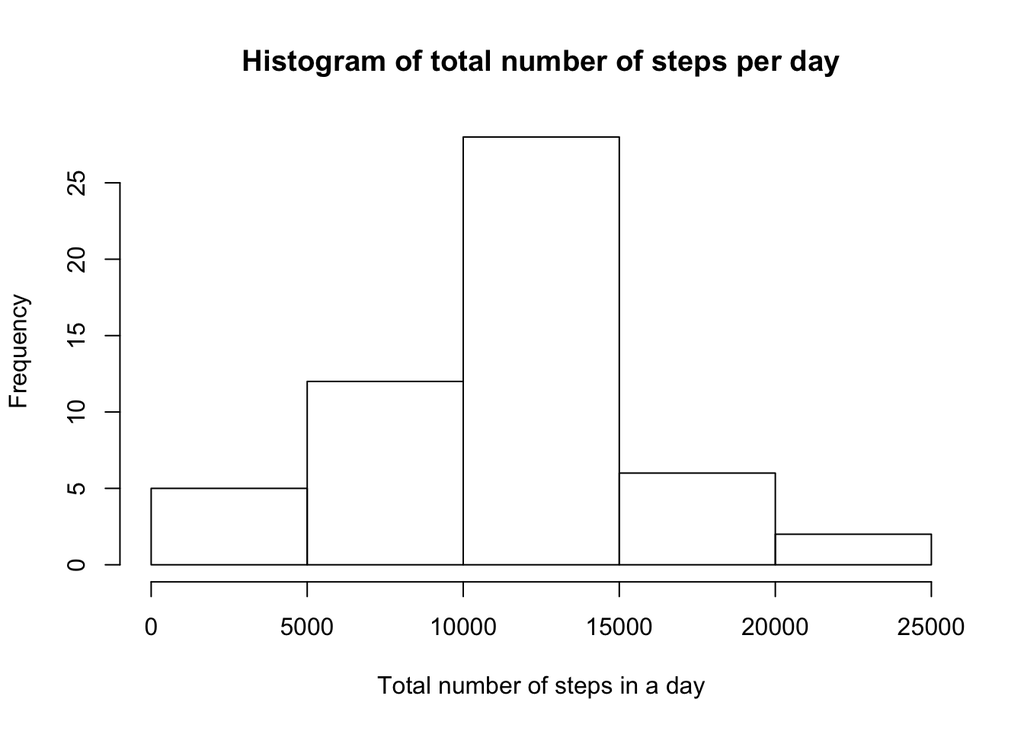

```r
hist(table_sum$steps, main="Histogram of total number of steps per day",
     xlab="Total number of steps in a day")
```

### Calculate and report the mean and median of the total number of steps taken per day

```r
neat_table <- matrix(c(mean(table_sum$steps),median(table_sum$steps)))
rownames(neat_table) <- c("Mean","Median")
colnames(neat_table) <- "Steps"
as.table(neat_table)
```

```
##           Steps
## Mean   10766.19
## Median 10765.00
```

## What is the average daily activity pattern?

### Make a time series plot (i.e. 𝚝𝚢𝚙𝚎 = “𝚕”) of the 5-minute interval (x-axis) and the average number of steps taken, averaged across all days (y-axis)

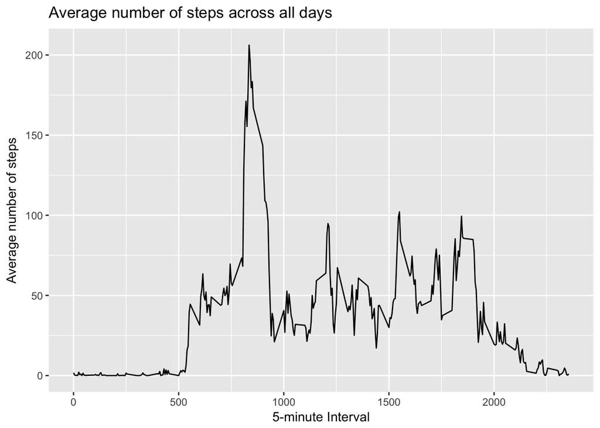

```r
#to left side ~: what is being aggregated and to right side: what is being used to aggregate
library(ggplot2)
steps_by_interval <- aggregate(steps ~ interval, activity1, mean)
ggplot(steps_by_interval,aes(x=interval,y=steps)) +
  ggtitle("Average number of steps across all days") +
  xlab("5-minute Interval") + ylab("Average number of steps") +
  geom_line()
```

###Which 5-minute interval, on average across all the days in the dataset, contains the maximum number of steps?

```r
# find row with max of steps
max_steps_row <- which.max(steps_by_interval$steps)

# interval corresponding to max number of steps:
answer <- steps_by_interval[max_steps_row, ]$interval
```

The 5-min interval which contains the maximum number of steps is 835

Total number missing values

```r
sum(is.na(activity$steps))
```

```
## [1] 2304
```

## 2. Devise a strategy for filling in all of the missing values in the dataset.

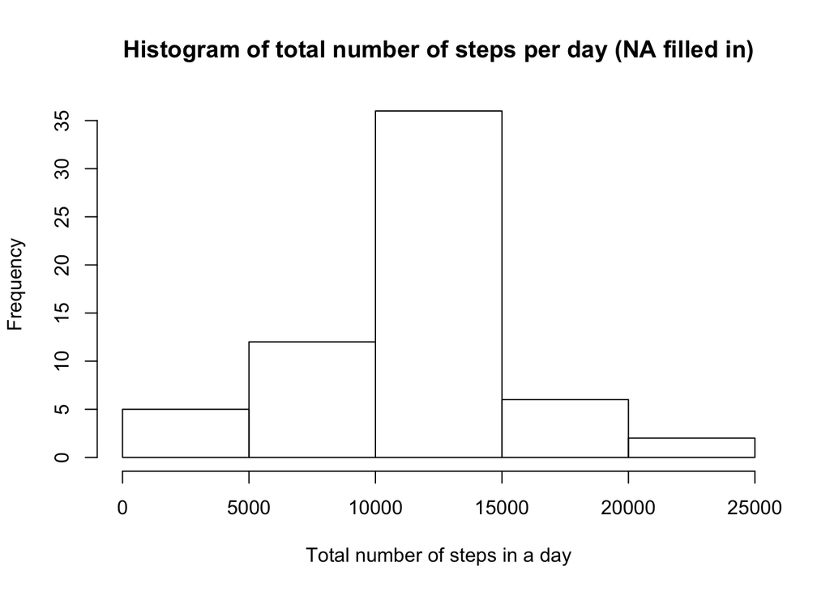

```r
activity_mod <- activity

# Loop through all the rows of activity, find the one with NA for steps.
# For each identify the interval for that row
# Then identify the avg steps for that interval in avg_steps_per_interval
# Substitute the NA value with that value

for (i in 1:nrow(activity_mod)) {
  if(is.na(activity_mod$steps[i])) {
    val <- steps_by_interval$steps[which(steps_by_interval$interval == activity$interval[i])]
    activity_mod$steps[i] <- val
  }
}

# Aggregate the steps per day with the imputed values
steps_per_day_impute <- aggregate(steps ~ date, activity_mod, sum)

hist(steps_per_day_impute$steps, main="Histogram of total number of steps per day (NA filled in)",
     xlab="Total number of steps in a day")
```

### Calculate and report the mean and median total number of steps taken per day.

### Do these values differ from the estimates from the first part of the assignment?

### What is the impact of imputing missing data on the estimates of the total daily number of steps?

```r
neat_table2 <- matrix(c(mean(steps_per_day_impute$steps),median(steps_per_day_impute$steps)))
rownames(neat_table2) <- c("Mean","Median")
colnames(neat_table2) <- "Steps"
as.table(neat_table2)
```

```
##           Steps
## Mean   10766.19
## Median 10766.19
```

Mean has not changed, Median increased slightly.

## Are there differences in activity patterns between weekdays and weekends?

### 1. Create a new factor variable in the dataset with two levels – “weekday” and “weekend” indicating whether a given date is a weekday or weekend day.

### 2. Make a panel plot containing a time series plot (i.e. 𝚝𝚢𝚙𝚎 = “𝚕”) of the 5-minute interval (x-axis) and the average number of steps taken, averaged across all weekday days or weekend days (y-axis). See the README file in the GitHub repository to see an example of what this plot should look like using simulated data.

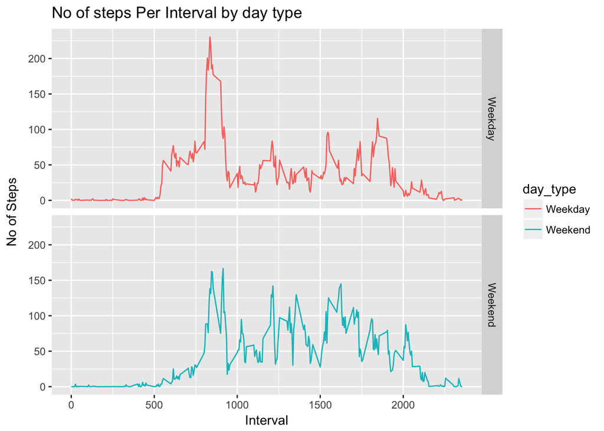

```r
#function check if day is weekday
#convert to date bc weekdays() works with POSIXt or Date.

week_day <- function(date_val) {
  wd <- weekdays(as.Date(date_val, '%Y-%m-%d'))
  if  (!(wd == 'Saturday' || wd == 'Sunday')) {
    x <- 'Weekday'
  } else {
    x <- 'Weekend'
  }
  x
}


# Apply the week_day function and add a new column called day_type to activity dataset
activity_mod$day_type <- as.factor(sapply(activity_mod$date, week_day))

#load the ggplot library
library(ggplot2)

# Create the aggregated data frame by intervals and day_type
steps_per_day_impute <- aggregate(steps ~ interval+day_type, activity_mod, mean)

# Create the plot
ggplot(steps_per_day_impute, aes(interval, steps)) +
  geom_line(aes(colour = day_type)) +
  facet_grid(day_type ~ .) +
  labs(x="Interval", y=expression("No of Steps")) +
  ggtitle("No of steps Per Interval by day type")
```